# The relationship between SAT scores and admission rates in U.S. colleges

Mohammad Boaisha

2018-12-23

## Preprocessing the dataset

First, we inspect the dataset:

```r
head(college)
```

| UNITID | OPEID | OPEID6 | INSTNM | CITY | STABBR | ZIP | ACCREDAGENCY | INSTURL | NPCURL | SCH_DEG | HCM2 | MAIN | NUMBRANCH | PREDDEG | HIGHDEG | CONTROL | ST_FIPS | REGION | LOCALE | LOCALE2 | LATITUDE | LONGITUDE | CCBASIC | CCUGPROF | CCSIZSET | HBCU | PBI | ANNHI | TRIBAL | … |
| --- | --- | --- | --- | --- | --- | --- | --- | --- | --- | --- | --- | --- | --- | --- | --- | --- | --- | --- | --- | --- | --- | --- | --- | --- | --- | --- | --- | --- | --- | --- |
| 100654 | 100200 | 1002 | Alabama A & M University | Normal | AL | 35762 | Southern Association of Colleges and Schools Commission on Colleges | www.aamu.edu/ | www2.aamu.edu/scripts/netpricecalc/npcalc.htm | 3 | 0 | 1 | 1 | 3 | 4 | 1 | 1 | 5 | 12 | NA | 34.78337 | -86.56850 | 18 | 10 | 13 | 1 | 0 | 0 | 0 | … |
| 100663 | 105200 | 1052 | University of Alabama at Birmingham | Birmingham | AL | 35294-0110 | Southern Association of Colleges and Schools Commission on Colleges | www.uab.edu | uab.studentaidcalculator.com/survey.aspx | 3 | 0 | 1 | 1 | 3 | 4 | 1 | 1 | 5 | 12 | NA | 33.50570 | -86.79935 | 15 | 9 | 15 | 0 | 0 | 0 | 0 | … |
| 100690 | 2503400 | 25034 | Amridge University | Montgomery | AL | 36117-3553 | Southern Association of Colleges and Schools Commission on Colleges | www.amridgeuniversity.edu | www2.amridgeuniversity.edu:9091/ | 3 | 0 | 1 | 1 | 3 | 4 | 2 | 1 | 5 | 12 | NA | 32.36261 | -86.17401 | 20 | 5 | 6 | 0 | 0 | 0 | 0 | … |
| 100706 | 105500 | 1055 | University of Alabama in Huntsville | Huntsville | AL | 35899 | Southern Association of Colleges and Schools Commission on Colleges | www.uah.edu | finaid.uah.edu/ | 3 | 0 | 1 | 1 | 3 | 4 | 1 | 1 | 5 | 12 | NA | 34.72456 | -86.64045 | 16 | 9 | 12 | 0 | 0 | 0 | 0 | … |
| 100724 | 100500 | 1005 | Alabama State University | Montgomery | AL | 36104-0271 | Southern Association of Colleges and Schools Commission on Colleges | www.alasu.edu | www.alasu.edu/cost-aid/forms/calculator/index.aspx | 3 | 0 | 1 | 1 | 3 | 4 | 1 | 1 | 5 | 12 | NA | 32.36432 | -86.29568 | 19 | 10 | 13 | 1 | 0 | 0 | 0 | … |
| 100751 | 105100 | 1051 | The University of Alabama | Tuscaloosa | AL | 35487-0166 | Southern Association of Colleges and Schools Commission on Colleges | www.ua.edu/ | financialaid.ua.edu/net-price-calculator/ | 3 | 0 | 1 | 1 | 3 | 4 | 1 | 1 | 5 | 13 | NA | 33.21187 | -87.54598 | 16 | 14 | 16 | 0 | 0 | 0 | 0 | … |

It seems like a huge dataset with 1800+ variables. We will have to select the most appropriate variables to my question.

Because the dataset has 1800+ variables, we will have to select the most appropriate variables to the question:

Is there a relationship between SAT scores and admission rates?

The columns that appear suitable are: * INSTNM * UNITID * SAT_AVG * SATVRMID * SATMTMID * SATWRMID * ADM_RATE_ALL * CONTROL

```r
#Load dplyr package to use the rename() function.
library(dplyr)

college_reduced_m <- college %>%
  # Reduce the dataset to only certain columns
  select(INSTNM,UNITID,SAT_AVG,SATVRMID,SATMTMID,SATWRMID, ADM_RATE_ALL,CONTROL) %>%
  # Rename the columns
  rename(Instituation_name = "INSTNM",
         unit_id = "UNITID",
         sat_average_score = "SAT_AVG",
         mid_sat_cr = "SATVRMID",
         mid_sat_mt = "SATMTMID",
         mid_sat_wr = "SATWRMID",
         admit_rate = "ADM_RATE_ALL",
         ownership = "CONTROL") %>%
  # Exclude private for-profit colleges
  filter(ownership != 3 ) %>%
  # Recode the ownership variable
  mutate(ownership = recode(ownership, "1" = "public", "2" = "private")) %>%
  # I chose to drop NA values early for the sake of modularity
  drop_na()
```

We end up with a much cleaner dataframe we can use for our analysis

```r
head(college_reduced_m)
```

| Instituation_name | unit_id | sat_average_score | mid_sat_cr | mid_sat_mt | mid_sat_wr | admit_rate | ownership |
| --- | --- | --- | --- | --- | --- | --- | --- |
| Alabama A & M University | 100654 | 849 | 425 | 420 | 414 | 0.8737754 | public |
| The University of Alabama | 100751 | 1202 | 550 | 555 | 540 | 0.5258519 | public |
| Auburn University | 100858 | 1217 | 575 | 585 | 570 | 0.8054338 | public |
| Faulkner University | 101189 | 972 | 500 | 500 | 470 | 0.4538021 | private |
| University of West Alabama | 101587 | 969 | 480 | 460 | 475 | 0.5310078 | public |
| University of Montevallo | 101709 | 1069 | 530 | 520 | 528 | 0.6542416 | public |

## Exploratory data analysis

We can find the summary statistic like so:

```r
# Calculate summary stats
college_summary <- college_reduced_m %>%
  group_by(ownership) %>%
  summarize(mean_cr = mean(mid_sat_cr, na.rm = TRUE),
            mean_mt = mean(mid_sat_mt, na.rm = TRUE),
            mean_wr = mean(mid_sat_wr, na.rm = TRUE),
            mean_admit = mean(admit_rate, na.rm = TRUE))

# Display summary stats
college_summary
```

| ownership | mean_cr | mean_mt | mean_wr | mean_admit |
| --- | --- | --- | --- | --- |
| private | 539.5429 | 542.1462 | 527.7842 | 0.6051118 |
| public | 517.2206 | 528.3419 | 500.2243 | 0.6795083 |

The summary statistics show some key insights such as:

- On average, public universities have lower admission standards than private universities.
- On average, private universities’ apllicants score higher in all sections of the SATs.

To visualize our findings we write the following code:

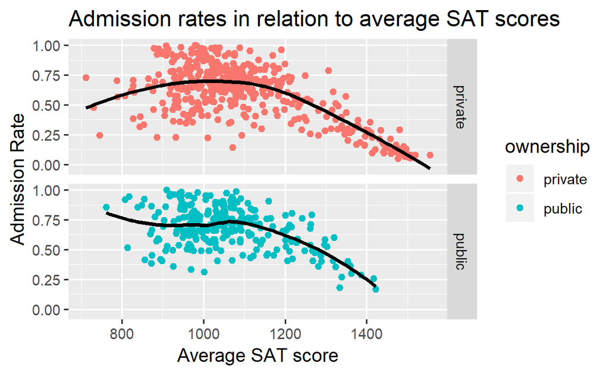

```r
ggplot(data = college_reduced_m, aes(x = sat_average_score, y = admit_rate, color = ownership)) +
  geom_point() +
  labs(x = "Average SAT score",
       y = "Admission Rate",
       title = "Admission rates in relation to average SAT scores") +
  facet_grid(ownership ~ .) +
  geom_smooth(color = "black", se = FALSE)
```

It appears that private universities tend to show a curvilinear relationship, meaning, private universities often admit applicants with higher scores until a certain point (around 1100~ SAT score), in contrast, public universities have some outliers that that can skew the relationship, this skew can be attributed to other factors that concern the nature of public universities (i.e. funding and seat availability)

The above visualization shows 703 observations, the pattern can be inspected by taking a small sample:

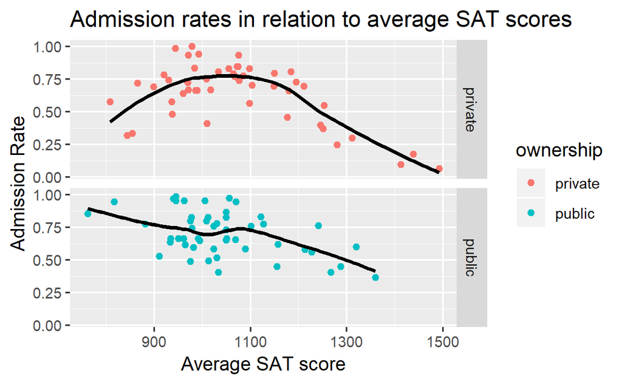

```r
# Since we will utilize the Random Number Generator, it's imperative to set a seed ID
# For consistent results and reproducibility
set.seed(451)

# Desired sample size for each category of "ownership"
n = 50 # multiply this by 2 for true sample size. The maximum N is 272

# Take a sample of public schools
college_public_sample <- college_reduced_m %>%
  filter(ownership == "public") %>%
  sample_n(size = n)

# Take a sample of private schools
college_private_sample <- college_reduced_m %>%
  filter(ownership == "private") %>%
  sample_n(size = n)

# Merge the two samples
college_sample_merged <- bind_rows(college_public_sample, college_private_sample)

# Visualize the merged sample dataframe
ggplot(data = college_sample_merged, aes(x = sat_average_score, y = admit_rate, color = ownership)) +
  geom_point() +
  labs(x = "Average SAT score",
       y = "Admission Rate",
       title = "Admission rates in relation to average SAT scores") +
  facet_grid(ownership ~ .) +
  geom_smooth(color = "black", se = FALSE)
```

Find the correlation coefficient for the population (public and private):

```r
cor(college_reduced_m$sat_average_score,college_reduced_m$admit_rate)
```

```
## [1] -0.5630919
```

Find the correlation coefficient for the sample (public and private):

```r
cor(college_sample_merged$sat_average_score,college_sample_merged$admit_rate)
```

```
## [1] -0.5045364
```

We observe similar results depsite sampling. Taking into consideration public and private schools, it appears that there is a moderate negative relationship. **In general, schools that have low SAT score applicants tend to have higher admission rates**